# Structuring and formatting documents, tables, and figures

Philippe Mongeon

## Plan

- Why structure matters
- Tools to structure your text
- Heading levels
- Word styles
- Word templates
- Zotero
- Formatting tables
- Formatting figures

## Why structure matters

- Your documents typically have readers, help them read and understand your work!
- A cluttered text without structure can reflect or be interpreted as a lack of understanding.
- Do it for you!

## Tools to structure your text

- A title is essential!
- Headings are almost unavoidable!
  - Example: **I**ntroduction, **M**ethod, **R**esults **a**nd **D**iscussion (IMRaD).
- Subheadings are generally recommended!
  - [APA guidelines](https://apastyle.apa.org/style-grammar-guidelines/paper-format/headings) for headings and subheadings formatting.
- Paragraphs are essential!
  - One paragraph per idea
  - Topic sentence, supporting sentences, concluding sentence.
- Bullet points and numbered lists are recommended when appropriate!

# Demo

Word styles, Word templates, Zotero.

# Tables and figures

## Formatting tables

Basic rules from Wilke (2019):

- Avoid vertical lines
- Avoid horizontal lines between data rows.
  - Use them at the top and bottom of the table and to separate column headers from the content of the table.
- Text is left-aligned.
- Numbers are right-aligned and use the same number of decimals (not more than necessary) throughout.
- Columns containing single characters are centred.
- The header fields are aligned with their data

## Example

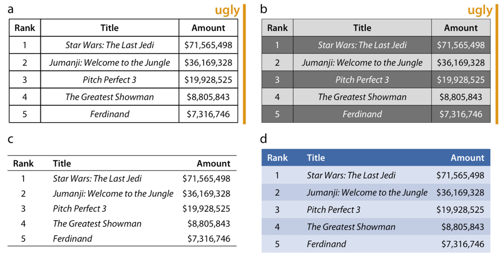

## Tip

In some cases, you may find it easier to

- create your table in Excel
- Copy it in Word (as a table, **not** as an image)
- Then use word to format the table.

## Formatting figures

- All axes should be labelled
- Principle of proportional ink (generally means the y-axis should start at 0).
- Use a colour palette only if it conveys information (not usually relevant unless more than two variables are used for the figure).
- No border, no shade, no 3D!
- For guidance on selecting appropriate graph types, see [MGMT2505 - Working with data course (ch. 10 to 12)](https://pmongeon.github.io/mgmt2605/ch10.html).

## Table and figure captions in Word

- Necessary to automatically generate lists of tables and figures.
- Particularly useful for longer documents (e.g., dissertations and theses).

## Navigation tools

- Navigation pane
- Table of content
- List of tables and figures

# Things to remember

- Good writing is difficult.
- Good writing takes time.
- The first draft is never (or should probably never be) the final draft.
- Practice makes… better.

## References

Wilke, C. 2019. *Fundamentals of Data Visualization: A Primer on Making Informative and Compelling Figures*. First edition. Sebastopol, CA: O’Reilly Media.